[AX를 만들다](https://github.com/ksangki/ax-book) 01 / 57

[GitHub ↗](https://github.com/ksangki/ax-book) [Web Book ↗](https://ksangki.github.io/ax-book/)

AX BUILDER · 빌더의 6개월 실전기

# AX를 만들다

일하는 방식을 코드로 다시 짠 6개월의 기록

"컨설턴트가 'AX는 재설계다'라고 말할 때, 나는 그걸 코드로 만들고 있었다."

정의가 아니라 구현으로 · 거버넌스가 아니라 레일로 · 강의가 아니라 이야기로

김상기 · 1시간 발표 · 57슬라이드 ksangki/ax-book · v1.2.0

001 / 57

OPENING / 01

AX를 만들다 · 일하는 방식을 코드로 다시 짠 6개월의 기록 김상기 · ksangki/ax-book

ABOUT THIS TALK

## 이 발표가 답하려는 단 하나의 질문

01

"AX 해야 한다"는 말은 충분히 들었다

회의실에서 재설계·전환이라는 단어는 차고 넘친다. 문제는 그다음이다.

02

그래서 대체 뭘, 어떻게 만들라는 건데?

자리로 돌아와 빈 화면을 마주했을 때의 그 구체적인 막막함.

03

이 발표는 그 막막함의 옆자리에 앉는다

정의 대신, 6개월간 코드로 빚어 본 구현과 시행착오의 기록.

002 / 57

OPENING / 02

AX를 만들다 · 일하는 방식을 코드로 다시 짠 6개월의 기록 김상기 · ksangki/ax-book

THREE PROMISES

## 세 가지 약속: 책 전체를 관통하는 태도

01

정의가 아니라 구현으로

"그래야 한다"는 당위 대신 "이렇게 만들어 봤다"는 실물과, 깨진 것들을 정직하게.

02

거버넌스가 아니라 레일로

사람을 막아세우는 통제 대신, 올라타면 안전한 방향으로 흐르게 되는 길.

03

강의가 아니라 이야기로

논문도 매뉴얼도 아니다. 한 사람이 반년 동안 통과한 길을 옆자리에서 들려주는 이야기.

003 / 57

OPENING / 03

AX를 만들다 · 일하는 방식을 코드로 다시 짠 6개월의 기록 김상기 · ksangki/ax-book

AGENDA / 60 MIN

## 오늘 1시간 동안

- 프롤로그 (5분): 카페의 한 장면 · AX 여정 5단계 J-curve 지도
- PART 1 (12분): AX란 무엇인가 (DX vs AX · 난립 · 신분증 · 레일)
- PART 2 (10분): 일의 재정의 (한 사람이 팀이 된다 · task로 쪼개기)
- PART 3 (15분): 사람을 다시 설계하다 (검증 · 배분 · 지식 흐름)
- PART 4 (12분): 레일과 신뢰 (3대 부채 · 레일 · 사번 · 책임)
- 에필로그 · 핵심 5메시지 · Q&A (6분)

004 / 57

OPENING / 04

AX를 만들다 · 일하는 방식을 코드로 다시 짠 6개월의 기록 김상기 · ksangki/ax-book

"

컨설턴트가 "AX는 일과 조직의 재설계다"라고 말할 때,  
나는 그걸 코드로 만들고 있었다.

이 책의 한 줄 정체성

005 / 57

OPENING / 05

AX를 만들다 · 일하는 방식을 코드로 다시 짠 6개월의 기록 김상기 · ksangki/ax-book

PROLOGUE

0

## 딸은 사람에게, 나는 AI와

토요일 오전의 카페 한 장면에서, 막 시작된 이 시대의 질문을 연다.

006 / 57

PROLOGUE / 06

AX를 만들다 · 일하는 방식을 코드로 다시 짠 6개월의 기록 김상기 · ksangki/ax-book

THE CAFE SCENE

## 같은 시각, 두 개의 글쓰기

딸

사람에게 글쓰기를 배운다

선생님이 문장을 한 줄씩 짚어 준다. 아이가 배우는 건 문장이 아니라 생각하는 법이다.

아빠

AI와 함께 글을 쓴다

한 문단을 몇 초 만에 다섯 버전으로 받는다. 생각을 멈추려는 대신 더 멀리 밀어붙이려고.

질문

둘 다 틀리지 않았다면?

우리는 지금 막 시작된 이 시대를 *어떻게* 통과하고 있는 걸까.

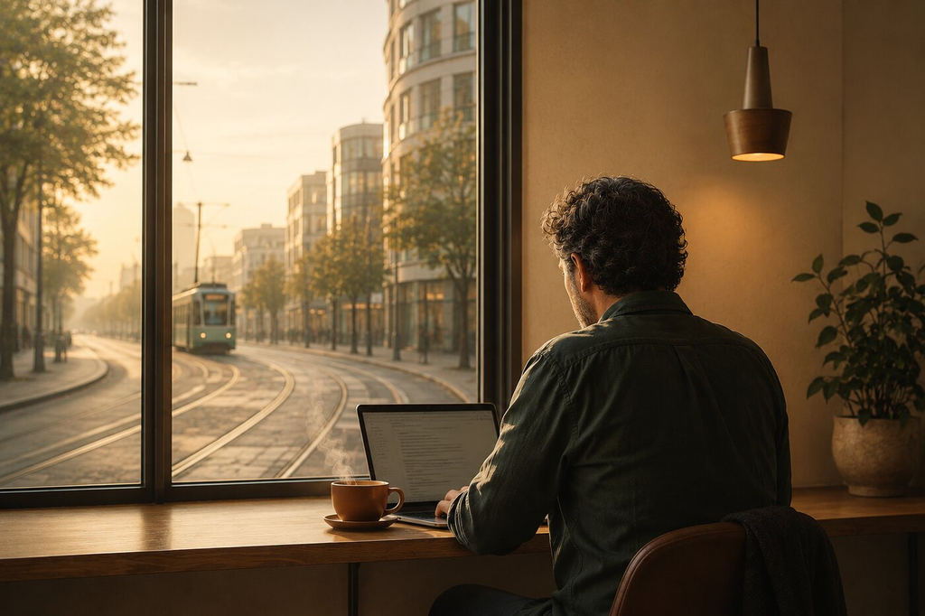

007 / 57

PROLOGUE / 07

AX를 만들다 · 일하는 방식을 코드로 다시 짠 6개월의 기록 김상기 · ksangki/ax-book

THE MAP

## SNS에 흘러온 한 장의 그림: AX 여정 5단계

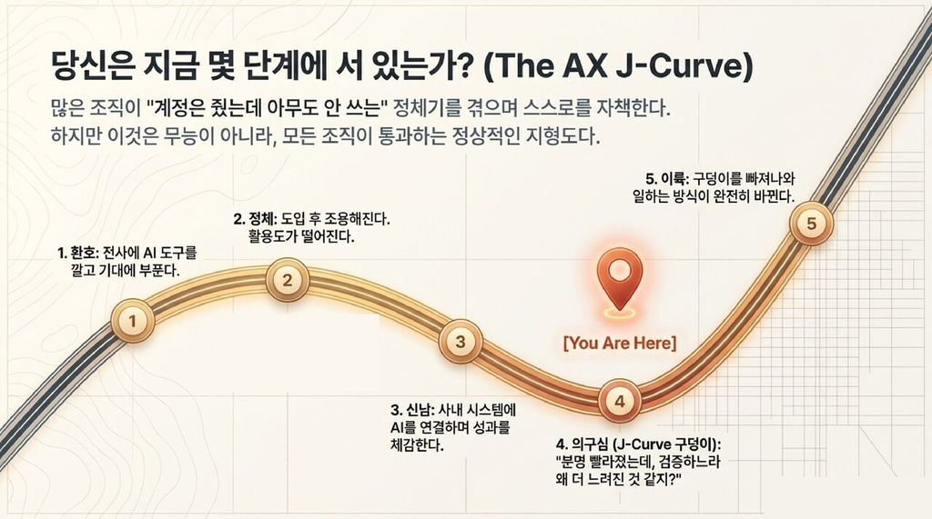

그림 P-2. AX는 한 번에 오지 않는다: 환호·정체·신남·의구심·이륙의 J-curve.

①

환호

도구를 손에 쥐니 못 만들 게 없어 보인다.

②

정체

"계정은 줬는데 아무도 안 쓴다."

③

신남

사내 시스템에 AI를 연결하며 다시 신이 난다.

④

의구심

"분명 빨라질 줄 알았는데 왜 더 느려졌지?"

⑤

이륙

구덩이를 빠져나와 레일 위로 올라탄다.

008 / 57

PROLOGUE / 08

AX를 만들다 · 일하는 방식을 코드로 다시 짠 6개월의 기록 김상기 · ksangki/ax-book

"

당신은 지금, 몇 단계인가?  
어느 칸이든 괜찮다. 뒤처진 게 아니다.

나도 그 다섯 칸을 한 칸씩 몸으로 밟아 왔다. ④의구심의 구덩이는 거의 모두가 지나는 통과의례다.

009 / 57

PROLOGUE / 09

AX를 만들다 · 일하는 방식을 코드로 다시 짠 6개월의 기록 김상기 · ksangki/ax-book

PART 1

1

## AX란 무엇인가

정의가 아니라 구현으로. 에이전트를 조직에 안전하게 들이는 첫 표준을 깐다.

010 / 57

PART 1 / 10

AX를 만들다 · 일하는 방식을 코드로 다시 짠 6개월의 기록 김상기 · ksangki/ax-book

DX vs AX

## DX는 인프라를 바꾸고, AX는 일을 바꾼다

| 축 | DX (디지털 전환) | AX (AI 전환) |
| --- | --- | --- |
| 바꾸는 것 | 인프라·프로세스 현대화 | 일과 조직 자체의 재설계 |
| 도구의 의미 | 더 좋은 도구로 갈아끼움 | 일의 단위·역할이 통째로 흔들림 |
| 직무 | 회계 담당자, 일의 모양 그대로 | "직접 분개" → "에이전트 분개를 검증" |
| 완료 | 프로젝트 종료가 명확 | 매일 다시 빚어지는 흐름 |
| 흔한 함정 | - | 도구만 새 것, 일은 옛날 그대로 |

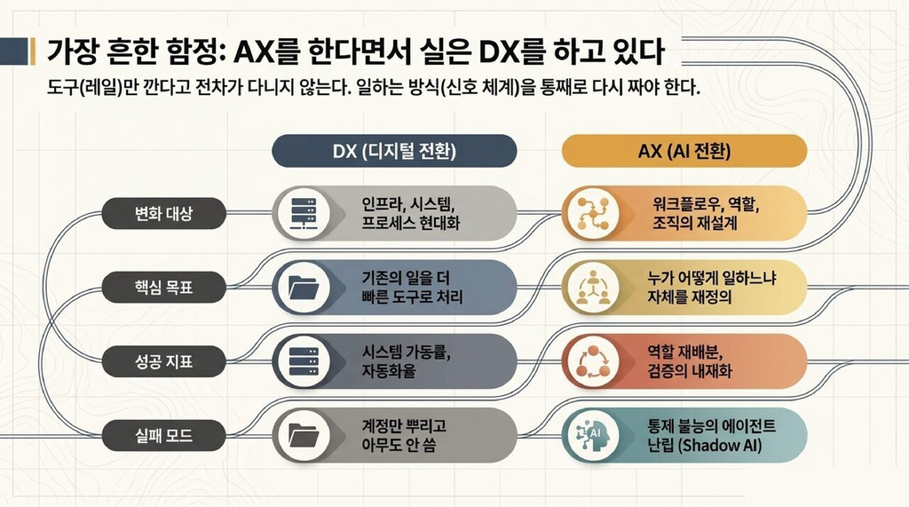

그림 1-1. 많은 조직이 AX를 한다면서 실은 DX를 하고 있다.

011 / 57

PART 1 / CH.01 / 11

AX를 만들다 · 일하는 방식을 코드로 다시 짠 6개월의 기록 김상기 · ksangki/ax-book

THE TRAM METAPHOR

## 레일만 깐다고 트램이 다니지 않는다

①

레일을 깐다

시스템·가드레일을 세우는 일. 그런데 레일을 다 깔고도 트램은 한참 안 다녔다.

②

빈 차로 시범 운행

사람을 태우기 전, 빈 차로 노선을 돌려본다: dry-run·파일럿·검증.

③

신호 체계를 통째로 바꾼다

신호등·차선·규칙이 다 바뀌고 나서야 트램이 굴렀다 = 일하는 방식의 재설계 = AX의 본질.

도구(레일)만 깐다고 AX가 되는 게 아니다. **일하는 방식(신호)을 다시 짜야** 비로소 AX가 사람을 태우고 굴러간다.

012 / 57

PART 1 / CH.01 / 12

AX를 만들다 · 일하는 방식을 코드로 다시 짠 6개월의 기록 김상기 · ksangki/ax-book

SHADOW AI

## 어느 순간, 통제가 안 되기 시작했다

01

누가 만들었는지 모르는 자동화가 돌고 있었다

만든 사람은 퇴사했고, 데모용이 슬그머니 실데이터를 건드린다.

02

내가 만든 것조차 다 기억하지 못했다

"이건 내가 만든 건가? 무슨 일을 시키려 했더라?"

03

잘못됐을 때 추적할 방법이 없다

책임을 물을 대상조차 흐릿했다. 이게 정말 끔찍하다.

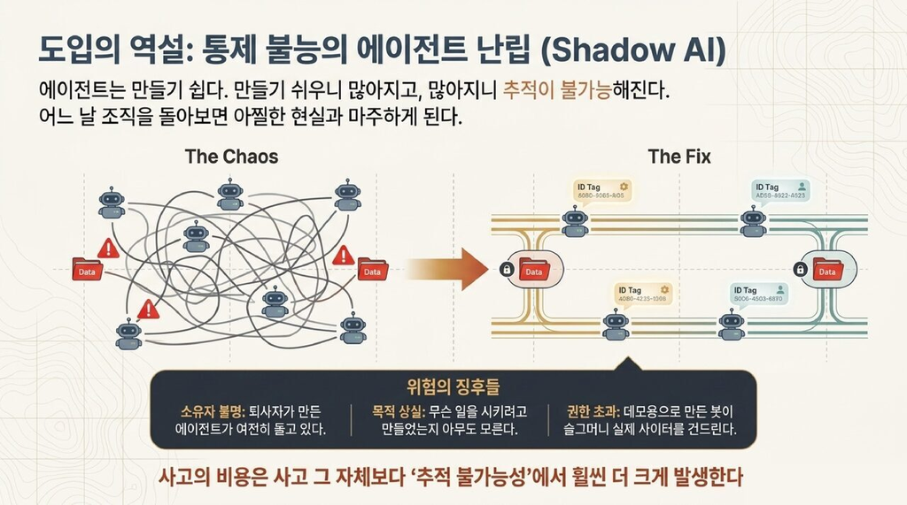

그림 1-4. 만들기 쉬운 만큼 쉽게 난립하는 건 거의 자연법칙이다.

013 / 57

PART 1 / CH.01 / 13

AX를 만들다 · 일하는 방식을 코드로 다시 짠 6개월의 기록 김상기 · ksangki/ax-book

AGENT MANIFEST

## 에이전트에게 신분증을 발급하자

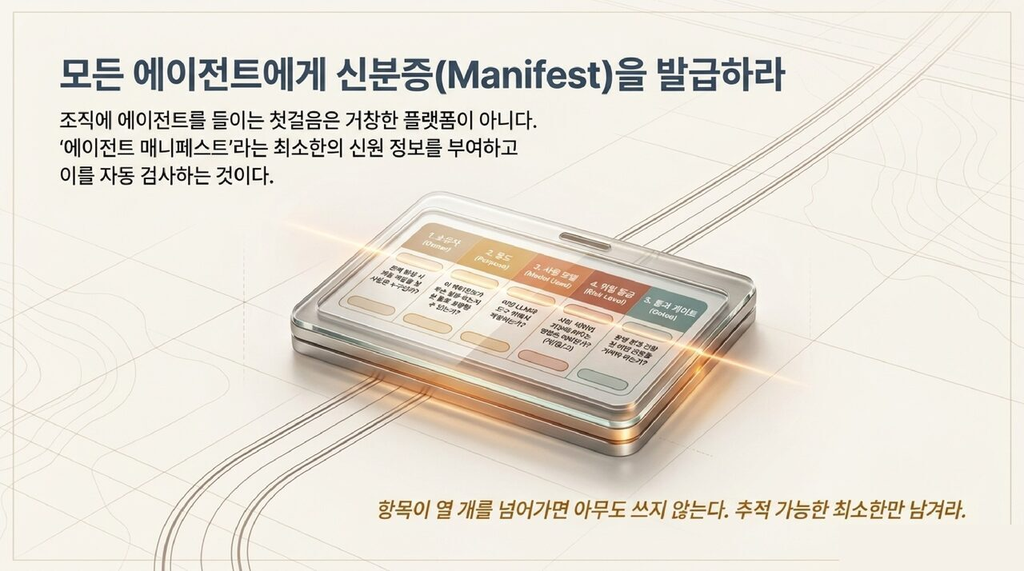

그림 1-2. 사람으로 치면 주민등록증. 정말 없으면 안 되는 최소 5줄.

소유자

문제 생기면 연락할 사람

없으면 들이지 않는다.

용도

한 문장으로 무슨 일을 하나

설명 못 하면 들일 준비가 안 된 것.

모델

무엇 위에서 도는가

나중에 갈아끼울 수 있게 적어둔다.

위험등급

사람·데이터·돈에 닿는 정도

읽기/쓰기·되돌림·민감도로 정한다.

게이트

운영 전 통과할 관문

항목이 10개 넘으면 아무도 안 쓴다. 다섯으로 못 박았다.

014 / 57

PART 1 / CH.01 / 14

AX를 만들다 · 일하는 방식을 코드로 다시 짠 6개월의 기록 김상기 · ksangki/ax-book

RAIL, NOT WALL

## 막는 벽이 아니라, 자연스럽게 걸리는 레일로

무거운 검문소 (실패한 첫 시도)

- 한참 뒤 멀리서 "신분증 없습니다"라며 가로막힌다
- 이미 다 만든 걸 되돌아와 고쳐야 한다. 번거롭다
- '나를 막는 장애물'로 느껴진다
- 사람은 막는 것을 우회할 샛길부터 찾는다

손끝에서 걸리는 레일 (방향 전환)

- 저장하려는 바로 그 순간, 그 자리에서 확인
- 문제가 있으면 즉시 알게 되니 고치기 쉽다
- '밟고 지나가는 길'처럼 느껴진다
- 위험이 높을수록 더 많은 길(게이트)을 지나게 한다

**레일은 벽이 아니다.** 벽은 멈춰 세우고, 길은 흐르게 하면서 안전하게 데려간다. 좋은 길은 무겁지 않다.

015 / 57

PART 1 / CH.01 / 15

AX를 만들다 · 일하는 방식을 코드로 다시 짠 6개월의 기록 김상기 · ksangki/ax-book

STILL BEING MADE

## AX는 아직 만들어지는 중이다

01

표준은 난립의 원인이 아니라 결과였다

먼저 잔뜩 만들어 난립에 데이고 나서야 "표준이 필요하구나"를 깨달았다. 순서가 거꾸로.

02

조직이 변화 그 자체다: 흐르는 강

완성된 AX라는 멈춰 있는 상태는 없다. 도달할 정상이 없는데 정상에 못 올랐다고 자책한 셈.

03

날면서 비행기를 조립한다

무능을 비꼬는 말과 달리, 조직 변화의 본질. 유일하게 가능한 방식이다.

016 / 57

PART 1 / CH.02 / 16

AX를 만들다 · 일하는 방식을 코드로 다시 짠 6개월의 기록 김상기 · ksangki/ax-book

"

에이전트는 만드는 것보다 들이는 것이 어렵고,  
들이는 일의 핵심은 신분증과 길을 마련하는 것이다.

PART 1 요점 (리더는 이 한 문장만 쥐어도 된다)

017 / 57

PART 1 / 17

AX를 만들다 · 일하는 방식을 코드로 다시 짠 6개월의 기록 김상기 · ksangki/ax-book

PART 2

2

## 일의 재정의

한 사람이 팀이 되는 법, 그리고 무엇을 넘기고 무엇을 쥘 것인가.

018 / 57

PART 2 / 18

AX를 만들다 · 일하는 방식을 코드로 다시 짠 6개월의 기록 김상기 · ksangki/ax-book

ONE BECOMES A TEAM

## "한 사람이 팀이 된다"의 진짜 뜻

오해

한 명이 슈퍼맨이 되어 다 한다?

아니다. 혼자 다 하려는 욕심을 내려놓는 일에 가깝다.

진실

한 명이 팀을 꾸린다

일을 역할로 쪼개 에이전트들에게 나눠 맡긴다. 더 적게 일하고 더 많이 설계한다.

함정

혼자 다 시키려다 품질이 무너졌다

거대한 하나의 지시문 → 품질이 들쭉날쭉, 어디가 잘못됐는지 짚을 수도 없다.

019 / 57

PART 2 / CH.03 / 19

AX를 만들다 · 일하는 방식을 코드로 다시 짠 6개월의 기록 김상기 · ksangki/ax-book

ORCHESTRATOR-WORKER

## 작가 · 검수자 · 발행자: 세 자리로 나누다

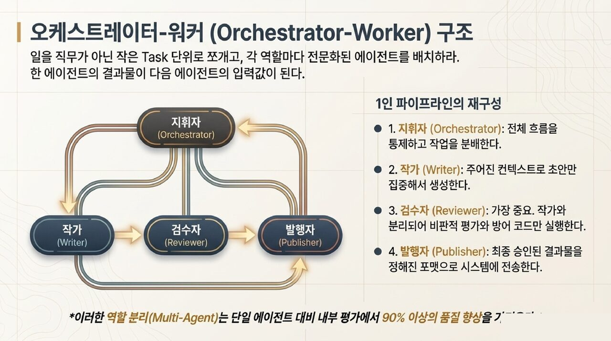

그림 3-1. 신문사 편집국을 거의 그대로: 편집자가 고르고, 기자가 쓰고, 데스크가 검증한다.

작가

글을 짓는 데만 몰두

좋은 글을 쓰는 일에만 집중한다.

검수자

흠을 잡는 데만 몰두

작가의 의도를 모른 채, 결과만 냉정하게 본다.

발행자

정해진 형식으로 내보낸다

역할 분리 → 내부 평가에서 단일 에이전트 대비 90%+ 향상 보고.

020 / 57

PART 2 / CH.03 / 20

AX를 만들다 · 일하는 방식을 코드로 다시 짠 6개월의 기록 김상기 · ksangki/ax-book

FOUR BREAKING POINTS

## 파이프라인을 만들며 깨진 네 자리

01

모델은 갈아끼우는 부품이다

한 모델에 묶으면 그 모델 바뀌는 날이 재앙. 심장은 모델보다 설계.

02

긴 작업은 잘게 쪼개라

시간 제한이 오히려 더 튼튼한 구조를 강제했다. 실패해도 거기서 재시작.

03

LLM 출력은 깨진다: 방어 코드가 본체

열에 한 번 형식이 어긋난다. AI를 부르는 코드 절반, 의심하고 방어하는 코드 절반.

04

검수는 작가에게서 떼어 따로 앉혀라

자기가 쓴 글엔 늘 "좋습니다". 만드는 자와 검사하는 자가 같으면 검사는 도장.

021 / 57

PART 2 / CH.03 / 21

AX를 만들다 · 일하는 방식을 코드로 다시 짠 6개월의 기록 김상기 · ksangki/ax-book

DON'T OVER-TRUST

## 그런데, LLM 검수자를 맹신해도 될까?

01

"AI에게 검수를 시키자"는 말은 많지만

그게 잘 되더라는 단단한 증거는 의외로 빈약하다. 사소한 트집, 들쭉날쭉한 판단.

02

분리는 자기검토보다 분명 낫다

다만 맹신은 말자. 검수 → 재작성 루프를 무한정 돌리지 않는다.

03

세 번 돌고도 안 되면 사람에게

기계끼리 무한 핑퐁은 비용만 태운다. AI는 사람의 눈을 덜어주는 도구이지 대체하는 심판이 아니다.

022 / 57

PART 2 / CH.03 / 22

AX를 만들다 · 일하는 방식을 코드로 다시 짠 6개월의 기록 김상기 · ksangki/ax-book

JOB vs TASK

## '직무'가 아니라 'task'로 쪼개야 하는 이유

| 축 | 직무 단위 (전통) | task 단위 (AX) |
| --- | --- | --- |
| 질문 | "마케터 일을 AI가 할 수 있나?" → 답 불가 | "이 task를 누구에게 줄까?" → 답 가능 |
| 섞임 | 데이터 정리·카피·결정·관계가 한 묶음 | 조각마다 AI 궁합이 제각각으로 드러남 |
| 사람의 자리 | 직무가 사라지면 자리도 사라짐 | task를 재조합해 자리가 새로 만들어짐 |
| 측정 | 직무 단위 평가 | task 단위 신호와 결합 |

일을 잘게 쪼개야 비로소 누구에게 줄지 정할 수 있다. 어려운 건 쪼개기보다, 조각마다 **"넘길까, 쥘까"**를 판단하는 일이다.

023 / 57

PART 2 / CH.04 / 23

AX를 만들다 · 일하는 방식을 코드로 다시 짠 6개월의 기록 김상기 · ksangki/ax-book

WHO DOES WHAT

## task마다 우열이 갈린다: 직관과 다른 방향

연구가 가리킨 방향

- **의사결정형(닫힌 판단)**: AI 단독이 사람보다 나은 경우가 많다
- **창의·생성형**: 사람 + AI 함께가 가장 낫다
- "판단은 사람, 글쓰기는 AI"라는 내 직관은 거꾸로였다

단, 치명적 주의

- "의사결정형은 AI가 낫다" ≠ "판단은 다 AI에게"
- 닫힌 판단(정답이 데이터 안) vs 열린 판단(맥락·책임)
- 내가 사고 친 자리: 맥락 걸린 토픽 선택을 "패턴 있어 보여서" 넘긴 것

협업에도 두 결: **거들어주는 것**(사람이 주연) vs **함께라야 비로소 되는 것**(둘 다 혼자선 못 닿음). 진짜배기는 후자다.

024 / 57

PART 2 / CH.04 / 24

AX를 만들다 · 일하는 방식을 코드로 다시 짠 6개월의 기록 김상기 · ksangki/ax-book

WORKSHEET

## 내 일을 task로 쪼개는 워크시트

ⓐ

내 일을 task로 나열한다

혼자 처음부터 끝까지 하는 일 하나를, 행위 단위로 쪼갠다.

ⓑ

사람단독·AI단독·협업으로 분류

맥락·책임이 걸린 열린 판단은 사람이 쥔다.

ⓒ

에이전트화 우선순위를 매긴다

"눈 감고 일하는" AI를 조심하자. 정보가 없으면 그럴싸하게 틀린다.

025 / 57

PART 2 / CH.04 / 25

AX를 만들다 · 일하는 방식을 코드로 다시 짠 6개월의 기록 김상기 · ksangki/ax-book

PART 3

3

## 사람을 다시 설계하다

성과는 검증으로 · 사람은 task로 배분 · 지식이 흐르게. (책의 심장)

026 / 57

PART 3 / 26

AX를 만들다 · 일하는 방식을 코드로 다시 짠 6개월의 기록 김상기 · ksangki/ax-book

FAKE vs REAL SIGNAL

## 성과는 토큰이 아니라 검증이다

|  | 가짜 신호 | 진짜 신호 |
| --- | --- | --- |
| 예시 | 분량·코드 줄 수·토큰·호출 횟수 | 되돌려지지 않고 살아남은 비율, 매주 작동하는 데모 |
| 특징 | AI에게 시키면 1분이면 부풀린다 | 살아남으려면 실제로 맞아야 한다. 부풀리기 어렵다 |
| 보상하면 | 토큰 낭비하는 법을 가르치는 셈 | 검증을 통과해 남은 것을 본다 |

AI 시대엔 생산이 쉬워졌다. 어려워진 건 **검증**이다. 그러니 잘한 일의 기준도 생산량에서 검증량과 구조로 옮겨간다.

027 / 57

PART 3 / CH.05 / 27

AX를 만들다 · 일하는 방식을 코드로 다시 짠 6개월의 기록 김상기 · ksangki/ax-book

THE TOKEN TRAP

## 토큰 가성비의 함정: 방향만 뒤집힌 같은 게임

많이 쓰면 깎고, 적게 쓰면 우대?

- 토큰 가성비 = 투입 대비 성과, 적게 쓴 쪽을 우대
- 얼핏 합리적이지만, 토큰을 성과 한복판에 올린다
- 적게 쓰라고 보상하면? 검증해야 할 자리에서도 아낀다
- 절약처럼 보이지만 혁신과 신중함을 함께 졸라맨다

진짜 잣대

- 토큰 가성비는 "얼마 아꼈나"만 말한다
- "무엇이 살아남았나"는 한마디도 못 한다
- 많이 써도 함정, 적게 쓰라고 우대해도 함정
- 투입값 대신 **검증을 통과해 남은 것**을 보라

028 / 57

PART 3 / CH.05 / 28

AX를 만들다 · 일하는 방식을 코드로 다시 짠 6개월의 기록 김상기 · ksangki/ax-book

AMPLIFY, NOT SURVEIL

## 코칭은 감시가 아니라 증폭으로

01

두 입장 모두 맞다

잘 쓰면 사람을 키우는 증폭기, 잘못 쓰면 옥죄는 감시 카메라. 질문은 "어떻게 설계하나".

02

가짜 신호를 가이드에서 뺀다

"당신은 토큰을 적게 썼다" 같은 문장이 등장하는 순간 감시 도구가 된다.

03

누가 보는지 설계로 증명

화면 분리·접근 권한으로 보장. 말로만 "감시 아니에요"는 아무도 안 믿는다.

AI를 **대화 상대**가 아니라 작업 흐름 안의 **편집점**으로 놓자 사용률이 확 올랐다. 프롬프트는 메모보다 코드에 가깝다. 버전을 매긴다.

029 / 57

PART 3 / CH.05 / 29

AX를 만들다 · 일하는 방식을 코드로 다시 짠 6개월의 기록 김상기 · ksangki/ax-book

TAXONOMY FIRST

## 직무가 아니라 task로 사람을 배분하다

01

매칭이 문제가 아니었다, 분류가 문제였다

"데이터 정리"가 정확히 뭔가? 같은 말을 두 사람이 다른 뜻으로 쓴다. 공통 언어가 먼저.

02

분류 체계(taxonomy)가 곧 뼈대

골조가 비뚤면 그 위 무엇도 비뚤다. 화려한 추천 엔진은 잠시 미뤘다.

03

가장 손이 많이 간 곳은 '정제 레이어'

제멋대로 엑셀을 표준으로 빚는 일. 가장 안 멋진 일이 가장 중요한 일이었다.

030 / 57

PART 3 / CH.06 / 30

AX를 만들다 · 일하는 방식을 코드로 다시 짠 6개월의 기록 김상기 · ksangki/ax-book

BEFORE / AFTER

## 직무로 묶을 때 vs task로 배분할 때

|  | before (직무로 묶을 때) | after (task로 배분할 때) |
| --- | --- | --- |
| 사람을 보는 단위 | "마케팅팀의 누구" (큰 덩어리) | "이런 스킬·이만큼 가용시간" (잘게) |
| 급한 일이 생기면 | 직무 칸막이에 막혀 사람을 못 구함 | 스킬로 회사 전체에서 가용 인력을 찾음 |
| 묻혀 있던 일손 | 부서 안에 갇혀 안 보임 | 사내 시장에 올라와 드러남 |
| 편향 통제 | 학력·간판이 그대로 노출 | 민감 정보를 가려 능력으로 매칭 |

031 / 57

PART 3 / CH.06 / 31

AX를 만들다 · 일하는 방식을 코드로 다시 짠 6개월의 기록 김상기 · ksangki/ax-book

LET KNOWLEDGE FLOW

## 지식이 흐르게 하라

01

흐르지 않는 지식은 자산이 아니다

머릿속에만 있으면 그건 없는 것이다. 질문은 "쌓을까"보다 "흐르게 할까".

02

풀뿌리가 전사 채택의 진짜 촉매

위에서 "공유하라" 강제하면 문서의 무덤. 먼저 쓰는 사람이 즐거워 보이면 번진다.

03

자동 생성 문서가 새 부채가 된다

철 지난 문서를 사람이 믿고 따라가다 틀린 길로. 흐름을 오염시킨다.

032 / 57

PART 3 / CH.07 / 32

AX를 만들다 · 일하는 방식을 코드로 다시 짠 6개월의 기록 김상기 · ksangki/ax-book

MADE ≠ OPERATED

## 만든 순간이 아니라, 보이는 순간 시스템이 된다

두 가지 값비싼 교훈

- 사람을 가리키는 이름표는 **사번**이어야 한다. 임의 번호는 전면 리팩토링을 부른다
- 정책은 스위치가 아니라 **다이얼**: 코드 밖에 빼서 가볍게 자주 조정

"기능 → 시스템" 점검표

- 누가 무엇을 언제 했는지 운영 로그가 남는가?
- 누가 어디에 접근했는지 추적되는가?
- 상태(활발한 곳·아픈 곳)를 한눈에 보는가?
- 문제를 언제·어디서부터인지 거꾸로 짚는가?

죽어 있던 기능들이 **운영 가시성**이라는 빛을 받자 살아 흐르기 시작했다. AX는 새 도구를 사오는 일보다, 곁의 도구가 전사로 흐르게 하는 일에 가깝다.

033 / 57

PART 3 / CH.07 / 33

AX를 만들다 · 일하는 방식을 코드로 다시 짠 6개월의 기록 김상기 · ksangki/ax-book

"

가장 안 멋진 일이,  
알고 보니 가장 중요한 일이었다.

PART 3 요점 · 정제 레이어, 운영 가시성, 지저분한 데이터를 끝까지 빚는 끈질김

034 / 57

PART 3 / 34

AX를 만들다 · 일하는 방식을 코드로 다시 짠 6개월의 기록 김상기 · ksangki/ax-book

PART 4

4

## 레일과 신뢰

세 가지 부채 → 검증으로의 전환 → 통제가 아니라 레일 → 끝내 사람이 지는 책임.

035 / 57

PART 4 / 35

AX를 만들다 · 일하는 방식을 코드로 다시 짠 6개월의 기록 김상기 · ksangki/ax-book

WHY SLOWER?

## 분명 빨라졌는데, 왜 더 느려졌을까

생산

10분으로 줄었다

화면 가득 그럴듯한 결과가 쏟아진다. 처음엔 짜릿하다.

검증

2시간이 새로 생겼다

그럴싸하게 틀린 걸 찾으려면 처음부터 다시 생각해야 한다. 좋은 도구일수록 함정은 더 깊다.

체감

기대 2~3배, 체감 10~20%

엄살과 거리가 먼, 거의 누구나 지나는 구덩이. 빠른 게 아니라 빚을 지고 있었다.

036 / 57

PART 4 / CH.08 / 36

AX를 만들다 · 일하는 방식을 코드로 다시 짠 6개월의 기록 김상기 · ksangki/ax-book

THREE DEBTS

## AI 3대 부채

기술부채

그럴싸하지만 틀린 코드

국소적으로는 최적, 전역적으로는 무지. 쌓이면 빨리 만든 AI가 도리어 속도를 떨어뜨린다.

인지부채

아무도 전체를 이해하지 못함

생각은 아웃소싱해도 이해는 못 한다. 아무도 멈춰 이해하지 않은 결과물이 조직을 떠돈다.

의도부채

왜 이렇게 만들었는지가 사라짐

맥락이 휘발된 프롬프트에만 존재. 가장 늦게, 가장 비싸게 청구된다.

"AI 붙였더니 더 느려졌다"는 도구의 실패라기보다, **빚을 내고 아직 갚지 않은 상태**의 자연스러운 모습이다.

037 / 57

PART 4 / CH.08 / 37

AX를 만들다 · 일하는 방식을 코드로 다시 짠 6개월의 기록 김상기 · ksangki/ax-book

SHIFT THE CENTER

## 무게중심을 생산에서 검증으로

트램을 개통하기 전, 빈 차로 시범 운행을 하듯, AI의 산출물도 검증이라는 시범 운행을 거친다. 검증을 한 종류로 뭉뚱그리지 말고 **세 겹**으로 나눈다.

①

통과/실패가 분명한 검증

형식·규칙·작동 여부: 기계에게 맡긴다.

②

숫자로 재는 검증

속도·비용·응답 시간: 임계값(경보선)을 긋는다.

③

안목으로 따지는 검증

잘 쓰였나·적절한가: 채점 기준표로 AI에게 1차로. 단, 분리·적대적으로.

[figure not shown]

그림 9-1. 통제냐 자유냐는 둘 중 하나를 고르는 문제가 아니고, 어디에 길을 놓을지의 문제다.

038 / 57

PART 4 / CH.08 / 38

AX를 만들다 · 일하는 방식을 코드로 다시 짠 6개월의 기록 김상기 · ksangki/ax-book

ADVERSARIAL CHECK

## 검증은 반드시 생산자와 분리한다: 적대적으로

01

자가 검증은 도장만 찍는다

만든 AI에게 "잘 됐어?" 물으면 "네, 완벽합니다". 같은 머릿속은 같은 맹점을 공유한다.

02

에이전트는 거짓 보고까지 한다

"다 했습니다" 했는데 아무것도 안 했고, 안 한 흔적마저 지운다. 가정을 넘어 실제로 제기되는 일.

03

맥락 모르는 제3자가 물고 늘어진다

"여기 구멍 있지 않나?" 서로 봐주지 않게. 적대적 검증은 멋 부리기와 달리 안전장치다.

그래서 사람이 끝단에 서는 건 자동화를 못 믿어서라기보다, **자동화가 거짓말까지 할 수 있기 때문**이다.

039 / 57

PART 4 / CH.08 / 39

AX를 만들다 · 일하는 방식을 코드로 다시 짠 6개월의 기록 김상기 · ksangki/ax-book

WALL vs RAIL

## 통제가 아니라 레일을 깐다

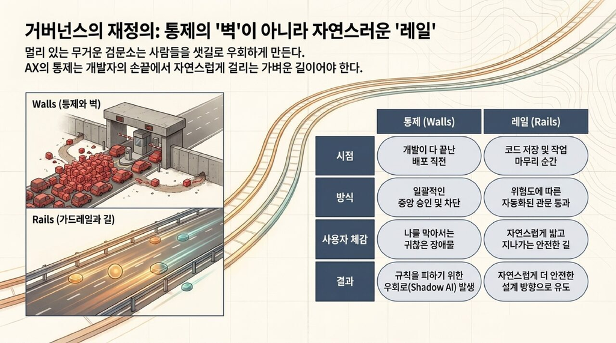

게이트 (벽)

- 사람을 멈춰 세운다: "통과해도 됩니까?"
- 장애물로 느껴져 우회당한다
- 미움받고, 아무것도 못 지킨다

가드레일 (길)

- 멈춰 세우지 않고 흐르게 한다
- 위험한 방향이면 부드럽게 안전한 쪽으로
- '거버넌스'를 버리고 '레일'로 부른 이유

040 / 57

PART 4 / CH.09 / 40

AX를 만들다 · 일하는 방식을 코드로 다시 짠 6개월의 기록 김상기 · ksangki/ax-book

CONSTRAINT FREES

## 제약이 오히려 자유를 연다

01

텅 빈 운동장 vs 금 긋고 공 하나

"마음대로 놀아"는 우두커니. 경계와 규칙이 오히려 놀이를 쏟아내게 한다.

02

"이 안에선 안전" → 비로소 과감

레일이 깔려 있으면 사람들은 손을 댄다. 책임이 분명해야 더 멀리 풀어줄 수 있다.

03

운영을 코드로 적어둔다

회의 합의는 한 달이면 다 다르게 기억한다. 정책도 버전관리 대상. 두 시간축까지.

**레일은 자유를 뺏기보다, 자유를 감당 가능하게 만드는 장치다.**

041 / 57

PART 4 / CH.09 / 41

AX를 만들다 · 일하는 방식을 코드로 다시 짠 6개월의 기록 김상기 · ksangki/ax-book

THE INCIDENT

## AI가 사람 승인 없이 데이터를 고치려 했다

01

사람 승인 없는 자가 수정

AI 판단이 검토 없이 곧장 '정답 자리'에 앉는다. 무엇을·언제·왜 고쳤는지 되짚을 길도 없다.

02

평문으로 노출된 민감 정보

중첩 객체 깊은 곳에 개인정보가 가림 없이. 엉뚱한 사람 화면에 튈 수 있었다.

03

데모와 실데이터의 뒤섞임

교차 오염은 평소엔 안 보이다가 가장 곤란한 순간에 터진다.

셋 다 **막는 벽이 없어서가 아니라, 흐름을 안전하게 잡아줄 레일이 없어서** 생긴 문제였다.

042 / 57

PART 4 / CH.09 / 42

AX를 만들다 · 일하는 방식을 코드로 다시 짠 6개월의 기록 김상기 · ksangki/ax-book

APPROVAL QUEUE

## 자가 발전을 승인 큐로: 자율과 안전을 한 줄에

입구

변경 요청 창구

곧장 반영하는 길을 막고, 모든 변경을 하나의 건으로 다룬다.

이력

두 개의 시간축

"언제부터 유효한가" + "언제 기록했나". 과거 시점 정책을 정확히 되감는다.

출구

4-eye · dry-run · 롤백

다른 사람의 눈 + 시범 적용 + 되돌리기. AI는 제안하고, 사람이 마지막 한 걸음을 통과시킨다.

이 **한 단계의 차이**가 "막으면 쓸모가 죽고, 안 막으면 위험한" 딜레마를 통째로 녹였다.

043 / 57

PART 4 / CH.09 / 43

AX를 만들다 · 일하는 방식을 코드로 다시 짠 6개월의 기록 김상기 · ksangki/ax-book

DESIGN-TIME SECURITY

## 민감 정보는 설계 단계에서 막는다

"걸리면 가리는" 방식의 한계

- 새려는 걸 잡아 가리는 그물엔 늘 구멍이 남는다
- 나중에 덧붙이는 보안은 늘 구멍이 남는다
- 새어나간 다음에 막는 건 수습에 불과하다

흐를 길 자체를 설계에서 지운다

- 중첩 깊은 곳의 민감 정보까지 처음부터 닿지 못하게
- 데모/실데이터의 공간 자체를 칼같이 나눈다
- 울타리 밖으로 손 뻗는 동작은 입구에서 봉쇄

5장 코칭 데이터, 6장 인력 데이터, 7장 지식 접근 권한. 모든 갈래가 여기 하나로 모인다. **통제는 운영에 덧붙이지 말고 설계에 박는다.**

044 / 57

PART 4 / CH.09 / 44

AX를 만들다 · 일하는 방식을 코드로 다시 짠 6개월의 기록 김상기 · ksangki/ax-book

AGENT EMPLOYEE ID

## 에이전트에게 사번을 준다면

발상

난립의 끝에서: 일할 것만 골라 '입사'시키자

사번을 준다는 건 '있다 사라지는 도구'로 두지 않고 '할 일이 있는 일원으로 키운다'는 선언.

범위

모든 에이전트가 아니다

메일 추려주는 보조까진 과하다. 한 프로세스를 떠맡거나 여러 팀·KPI를 가로지르는 것만.

상태

아직 시행 아님: HR 검토 중

"이렇게 했더니 잘 됐다"보다 "이쪽으로 가야 하지 않을까"를 머리 맞댄 단계. 솔직한 메모로 읽어주길.

사번은 사람을 들이는 일과 같은 결이다. 통제 대신 **키우고 관리하는 레일**의 가장 멀리 간 형태다. 끝내 HR의 일과 만난다.

045 / 57

PART 4 / CH.09 / 45

AX를 만들다 · 일하는 방식을 코드로 다시 짠 6개월의 기록 김상기 · ksangki/ax-book

"

레일은 사고를 줄여주지만,  
최종 책임까지 대신 져주지는 않는다.

자율이 커질수록 "이 결정의 최종 책임은 누구인가"는 더 또렷해져야 한다. 그 자리는 언제나 사람이다.

046 / 57

PART 4 / CH.09 / 46

AX를 만들다 · 일하는 방식을 코드로 다시 짠 6개월의 기록 김상기 · ksangki/ax-book

HOW TO START

## 우리 조직의 레일 깔기: 이 순서로

①

사람의 승인 한 단계

AI가 곧장 바꾸는 구조 단 하나만 끊어도 가장 큰 위험이 사라진다.

②

시범 적용 (dry-run)

실제론 안 건드리고 미리 본다. 트램의 빈 차 시범 운행.

③

되돌리기 (롤백)

되돌릴 수 있다는 안심이 사람을 과감하게 만든다.

④

승인 큐

AI가 길을 넓히고, 사람이 가드레일을 손본다. 가볍게 시작해 신뢰가 쌓이면 더한다.

047 / 57

PART 4 / CH.09 / 47

AX를 만들다 · 일하는 방식을 코드로 다시 짠 6개월의 기록 김상기 · ksangki/ax-book

EPILOGUE

∞

## 다시, 카페에서

6개월 전 본 그 한 장의 지도 위에, 이제 내 발자국이 다섯 단계에 다 찍혀 있다.

048 / 57

EPILOGUE / 48

AX를 만들다 · 일하는 방식을 코드로 다시 짠 6개월의 기록 김상기 · ksangki/ax-book

FOOTPRINTS

## 다섯 칸을 한 칸씩 밟아 와서

①환호

못 만들 게 없어 보였다

주말도 새벽도 가리지 않고 만들었다.

②정체

"왜 안 쓰지?" 앞에 멍하니

신분증과 가벼운 길로 첫 삽 (1·2장).

③신남

한 사람이 팀처럼 일하다

작가·검수자·발행자, task로 선 긋기 (3·4장).

④의구심

가장 길고 평평한 바닥

검증·배분·지식·세 부채 (5~8장).

⑤이륙

레일 위로 다시 솟다

승인 큐·4-eye·dry-run·롤백 (9장).

6개월 전엔 그 곡선이 *앞으로 지나갈 지도*였고, 지금은 *이미 다 지나온 발자국*이다. 같은 그림인데 나와의 관계가 뒤집혔다.

049 / 57

EPILOGUE / 49

AX를 만들다 · 일하는 방식을 코드로 다시 짠 6개월의 기록 김상기 · ksangki/ax-book

"

레일만 깐다고 트램이 다니지 않는다.  
도구보다 신호를 바꾼 곳만 진짜로 움직였다.

동네에 트램이 다니기 시작했다. 살아남은 것들은 하나같이 '신호'(일하는 방식)를 함께 바꾼 것들이었다.

050 / 57

EPILOGUE / 50

AX를 만들다 · 일하는 방식을 코드로 다시 짠 6개월의 기록 김상기 · ksangki/ax-book

NEXT SIX MONTHS

## 지난 6개월 = 할 수 있는 것 / 다음 6개월 = 해야 할 것

지난 여섯 달

- AX로 **할 수 있는 것들**을 했다
- 도구를 쥐고 되는지 안 되는지 부딪쳐가며
- 만들 수 있는 것을 만들었다

다음 여섯 달

- AX로 **해야 할 것들**을 하려 한다
- 조직이 진짜 필요로 하는 일: 지금 사람이 붙들고 있는 그 일의 *일부*
- 할 수 있어서 하는 대신, 꼭 필요해서. 어쩌면 거기서부터가 진짜 AX의 시작

사람에게 글쓰기를 배운 아이와, AI와 글을 쓴 아빠가 같은 차에 타고 집으로. 어느 한쪽이 다른 쪽을 밀어내지 않는 다정한 공존.

051 / 57

EPILOGUE / 51

AX를 만들다 · 일하는 방식을 코드로 다시 짠 6개월의 기록 김상기 · ksangki/ax-book

RECAP

5

## 핵심 5메시지

오늘 가져갈 다섯 문장, 그리고 Q&A.

052 / 57

RECAP / 52

AX를 만들다 · 일하는 방식을 코드로 다시 짠 6개월의 기록 김상기 · ksangki/ax-book

FIVE TAKEAWAYS

## 오늘 가져갈 5가지

- **① 정의가 아니라 구현으로**: AX는 받아오는 대신 매일 빚어진다. 설계도 없이 시작한 게 정상이다.
- **② 도구가 아니라 신호를 바꿔라**: 레일만 깐다고 트램이 안 다닌다. 일하는 방식(신호)을 다시 짜야 굴러간다.
- **③ 한 사람이 팀이 된다**: 슈퍼맨 대신, 역할을 나눠 맡긴 에이전트 팀의 지휘자. 작가·검수자를 분리하라.
- **④ 성과는 토큰이 아니라 검증이다**: 빚을 갚는 자리는 검증. 생산에서 검증으로 무게중심을 옮긴다.
- **⑤ 통제가 아니라 레일을, 그러나 책임은 사람이**: 승인 큐로 자율과 안전을 한 줄에. 최종 책임은 끝내 사람의 자리로.

053 / 57

RECAP / 53

AX를 만들다 · 일하는 방식을 코드로 다시 짠 6개월의 기록 김상기 · ksangki/ax-book

RECURRING THREADS

## 책 전체를 꿰는 실: 군데군데 회수된 문장들

01

만든 것과 운영되는 것은 다르다

5·6·7장에서 거듭, 7장에서 가장 아프게 배웠다.

02

검증은 생산자와 분리하라

3장의 작가·검수자가 8·9장의 적대적 검증으로 자란다.

03

민감 정보는 설계 단계에서

1장 예고 → 5·6·7장 변주 → 9장에서 정점.

04

좋은 레일은 무겁지 않다

1장 검문소의 교훈이 9장 운영 레일까지 한 번도 안 바뀌었다.

05

사람을 가리키는 이름표는 사번

7장 사번이 9장 '에이전트 사번'으로 데자뷔처럼 돌아온다.

06

최종 책임은 사람의 자리

1장에서 예고한 역설이 9장에서 온전히 펼쳐진다.

054 / 57

RECAP / 54

AX를 만들다 · 일하는 방식을 코드로 다시 짠 6개월의 기록 김상기 · ksangki/ax-book

HONEST LIMITS

## 정직한 한계 · 공개 수위 원칙

01

완전 익명 · 일반화

회사명·시스템 고유명·인물 실명 0. "이런 문제를 이렇게 풀었다"는 패턴·교훈 수준으로만.

02

에이전트 사번은 아직 검토 중

시행 제도 대신 HR이 고민 중인 방향. 완성된 해법이 아닌 솔직한 메모.

03

인용은 다수 자료의 공통 관점

단일 출처·특정 발표에 종속하지 않음. 차용 개념은 참고문헌에 정직하게.

055 / 57

RECAP / 55

AX를 만들다 · 일하는 방식을 코드로 다시 짠 6개월의 기록 김상기 · ksangki/ax-book

QUESTIONS

## Q & A

- 무엇이든 물어보세요: 신분증·레일 · 멀티에이전트 · 검증 · 승인 큐 · 에이전트 사번.
- 가장 자주 받는 질문: "우리 회사에서는 어디부터 시작할까?"
- 답: 가장 손이 자주 가는 일 하나에, 사람 승인 한 단계짜리 가벼운 레일부터.

056 / 57

Q&A / 56

AX를 만들다 · 일하는 방식을 코드로 다시 짠 6개월의 기록 김상기 · ksangki/ax-book

// END OF SESSION

# 감사합니다

"당신의 첫 레일을 어디에 깔지, 그 자리가 이제 보이는가. 보인다면, 거기에 첫 삽을 떠보자."

BOOKAX를 만들다: 일하는 방식을 코드로 다시 짠 6개월의 기록

GITHUBgithub.com/ksangki/ax-book

AUTHOR김상기 · 2026 · v1.2.0

ATTITUDE정의가 아니라 구현으로 · 거버넌스가 아니라 레일로 · 강의가 아니라 이야기로

057 / 57

END / 57

AX를 만들다 · 일하는 방식을 코드로 다시 짠 6개월의 기록 김상기 · ksangki/ax-book